# Music Genre Classification

Based on Song Sentiment

Aleksandra Gawor, Paulina Kułakowska

## 1. Introduction

#### 1.1. Research questions

In this paper we aim to utilize text mining, NLP and sentimental analysis to mine for patterns in associating the sentiments within a song with its genre. Is it possible to associate the mood of a song with the genre? Are some words more popular for a certain genre and appear more frequently? Is it possible to predict the genre basing only on the sentiment of a song and its lyrics?

#### 1.2. Literature overview

The field of Natural Language Processing in music has emerged to improve automatic tools for music classification and recommendation. Most of research for classyfying the genre based on mood of a song used features like the sentiment of song’s lyrics, but also audio features, which we lack in our analysis.

## 2. Methodology

In our analysis we focused solely on processing the lyrics of songs and extracting the polarity, and proportions of words negative vs. positive to use them later as features for predicting the genre of a song. Th implemented Machine Learning method was the Support Vector Machine (SVM) algorithm, which is a popular tool in text mining and sentimental analysis, also known as good for dealing with multiclass classification. We would like to classify about 10 classes, i.e. 10 different music genres, using sentiment charactersitics of songs lyrics.

#### 2.1. Data set

For the sake of analysis, we used Kaggle’s dataset 380,000+ lyrics from MetroLyrics. The initial data consisted of 339277 observations of 6 variables. Our dataset is a sample of 20000 rows.

#### 2.2. Text preprocessing

The first step was to draw a sample from our data and remove subspaces that were included in our data set.

```r
### draw data sample
data.sample <- data[sample(nrow(data), 20000),]

lyrics <- subset(data.sample, data.sample != "")
```

Then, we did a tokenization, which breaks the text into individual tokens and transforms it into a data structure, in our case, unnested into a word–i.e. extracting words from lyrics.

```r
lyrics <- lyrics %>% unnest_tokens(word, lyrics)
```

After tokenization it was time to remove all weird characters from the newly created “word” column.  
Because some songs included special or foreign language characters there was a need to get rid of them. Also, we needed to exclude some typical for lyrics phrases, like “chorus”, “verse” etc. and lyrics ornaments such as “lala”, “ooh”, “yeah” that do not have any meaning.

```r
lyrics <- lyrics %>%
  filter(!str_detect(word,"a"),
         word != "la",
         word != "de",
         word != "chorus",
         word != "oh",
         word != "ooh",
         word != "woo",
         word != "verse",
         word != "yeah",
         word != "uh",
         word != "x2",
         word != "2x",
         word != "x3",
         word != "x4",
         word != "ho",
         word != "mmm",
         word != " "
         )
```

It was also important to get rid of numbers and stop words. These two factors do not have any inflence on our analysis, so it was not neccessary not to include them.

```r
# remove numbers
lyrics$word <- replace_number(lyrics$word, num.paste = FALSE, remove = TRUE)
```

```r
# remove stop words
lyrics <- lyrics %>% anti_join(stop_words)
```

Our songs in the dataset included also stop words not only from English but also from other foreign language songs. There was, therefore, a need to remove Spanish and French stop words as well.

```r
custom_stop_words1 <- bind_rows(stop_words,
                               data_frame(word = quanteda::stopwords("spanish"),
                                          lexicon = "custom"))
custom_stop_words2 <- bind_rows(stop_words,
                               data_frame(word = quanteda::stopwords("french"),
                                          lexicon = "custom"))


lyrics <- lyrics %>%
  anti_join(custom_stop_words1)
lyrics <- lyrics %>%
  anti_join(custom_stop_words2)
lyrics <- lyrics %>%
  mutate(word = iconv(word, from = "latin1", to = "ASCII")) %>%
  filter(!is.na(word))
```

We could also apply word stemming to cut off endings of words with similar meaning and thus also same sentiment. However, the same word in different form may be important for our analysis, and we decided to keep them.

```r
# possible word stemming
# lyrics$word <-SnowballC::wordStem(lyrics[[6]], language = 'en')
```

All the rows in the database have complete cases and no missing values. Then, we were able to find most popular words.

```r
data.words.count <- lyrics %>% count(word, sort=T)
kable(head(data.words.count))
```

| word | n |
| --- | --- |
| love | 17937 |
| time | 10163 |
| life | 6553 |
|  | 6222 |
| feel | 6176 |
| night | 5254 |

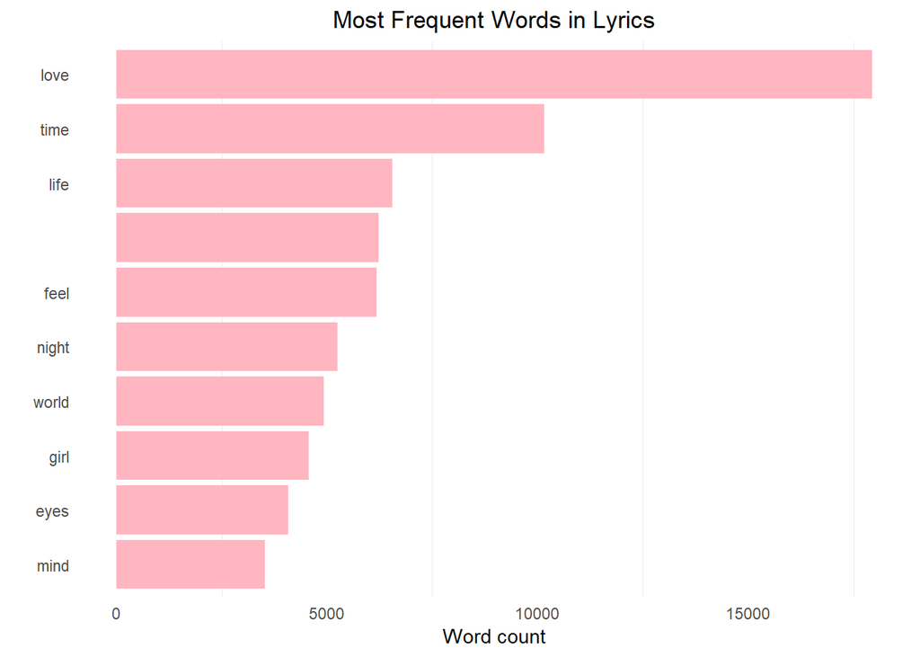

```r
# most frequent words
lyrics %>%
  count(word, sort = TRUE) %>%
  top_n(10) %>%
  ungroup() %>%
  mutate(word = reorder(word, n)) %>%
  ggplot() +
  geom_col(aes(word, n), fill = "lightpink") +
  theme_minimal() +
  theme(legend.position = "none",
        plot.title = element_text(hjust = 0.5),
        panel.grid.major = element_blank()) +
  xlab("") +
  ylab("Word count") +
  ggtitle("Most Frequent Words in Lyrics") +
  coord_flip()
```

We can clearly see, that the most popular word in music is “love”. But what is “love” usually connected with?

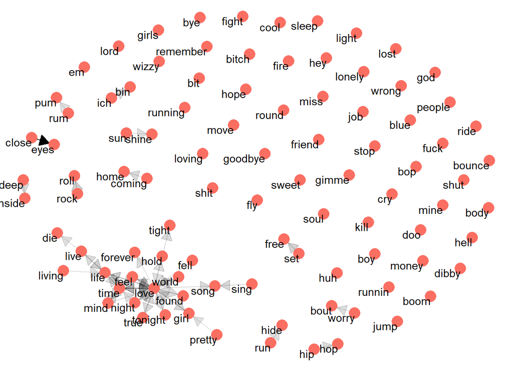

```r
lyrics_bigrams <- lyrics %>% unnest_tokens(bigram, word, token = "ngrams", n=2)

bigrams_sep <- lyrics_bigrams %>% separate(bigram, c("word1", "word2"), sep=" ")

bigrams_fil <- bigrams_sep %>%
filter(!word1 %in% stop_words$word) %>%
filter(!word2 %in% stop_words$word)

bigram_counts <- bigrams_fil %>%
count(word1, word2, sort = TRUE)

bigram_graph <- bigram_counts %>%
  filter(n > 100) %>%
  graph_from_data_frame()

set.seed(123456)
a <- grid::arrow(type = "closed", length = unit(.15, "inches"))

ggraph(bigram_graph, layout = "fr") +
  geom_edge_link(aes(edge_alpha = n), show.legend = FALSE,
                 arrow = a, end_cap = circle(.07, 'inches')) +
  geom_node_point(color = "#fb6f62", size = 5) +
  geom_node_text(aes(label = name), vjust = 1, hjust = 1) +
  theme_void()
```

Our next step was to group all the data according to the column that contained name of the song.

```r
lyrics <- lyrics %>%
  group_by(song)
```

#### 2.3. Mood labelling and sentimental analysis

Our goal was to see most popular words by positive or negative sentiment.

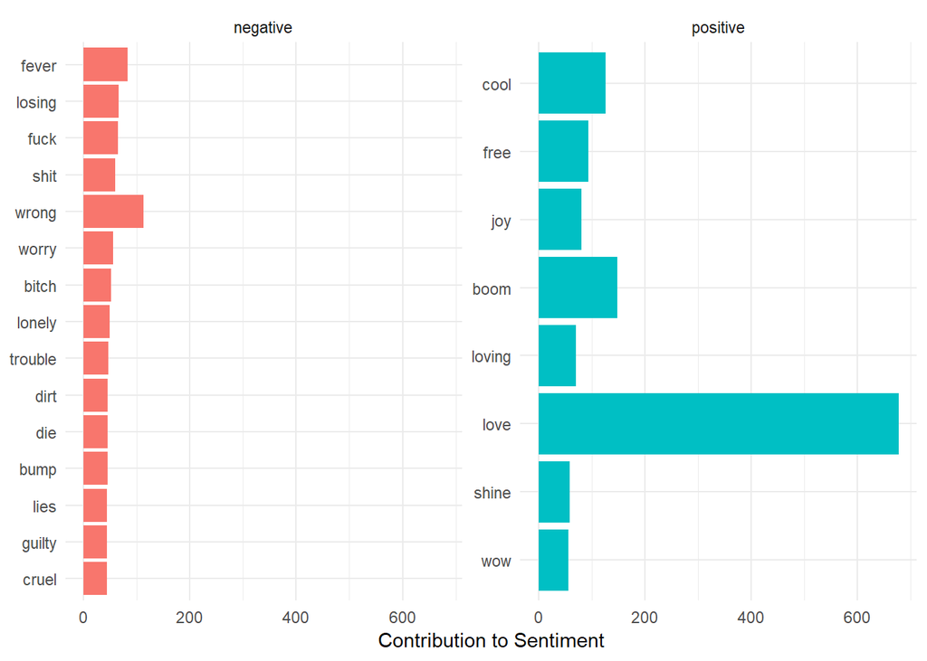

```r
  lyrics %>% inner_join(get_sentiments("bing")) %>%
  count(word, sentiment, sort = T) %>%
  group_by(sentiment) %>%
  top_n(15) %>%
  ungroup() %>%
  mutate(word = reorder(word, n)) %>%
  ggplot(aes(word, n, fill = sentiment)) +
  geom_col(show.legend = F) +
  theme_minimal() +
  facet_wrap(~ sentiment, scales = "free_y") +
  labs(y = "Contribution to Sentiment", x = NULL) +
  coord_flip()
```

Next step was to look into our data also in a form of a wordcloud, which also visualizes the negative and postive distinction.

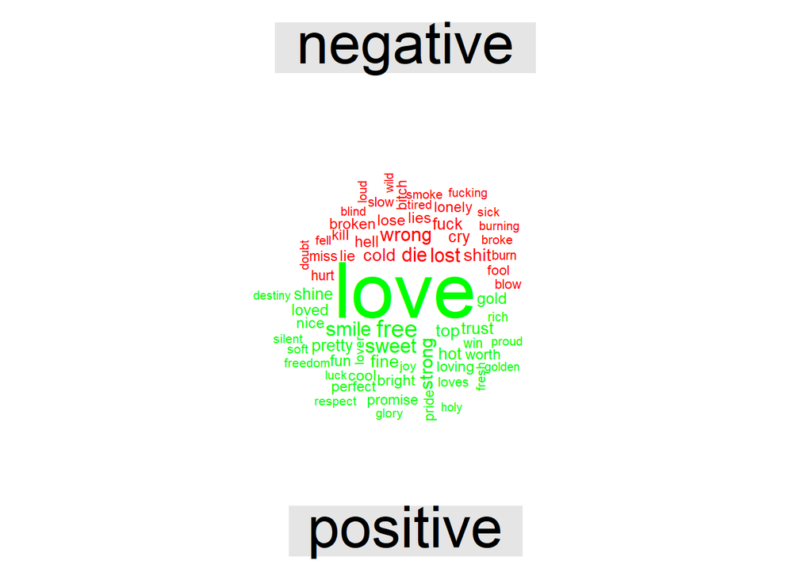

```r
lyrics %>%
  inner_join(get_sentiments("bing")) %>%
  count(word, sentiment, sort=TRUE) %>%
  acast(word ~ sentiment, value.var = "n", fill = 0) %>%
  comparison.cloud(colors = c("red", "green"),
                   max.words=70)
```

We can also find most frequent words across genres. For that, we again used the wordcloud, yet with several groups. In this part of the project we needed to get rid of ‘Not Avalibale’ and ‘Other’ types from genre.

```r
lyrics <-lyrics[!(lyrics$genre=="Not Available"),]
lyrics <-lyrics[!(lyrics$genre=="Other"),]

lyrics <- na.omit(lyrics)
```

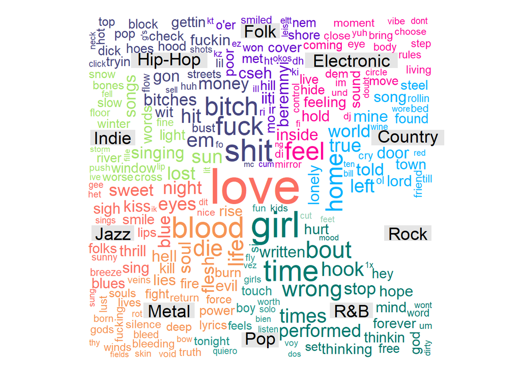

```r
# several groups (genres) wordcloud

lyrics %>%
  count(word, genre, sort=TRUE) %>%
  acast(word ~ genre, value.var = "n", fill = 0) %>%
  comparison.cloud(colors = c("#00B2FF", "#FF0099", "#6600CC","#464680",
                              "#a4e46b", "#fb6f62","#f69454", "#24978d","#01796f","#96ceb4",
                              "#ffeead","#ffad60","#5bc0de"),
                   max.words=1000,title.size=1.4)
```

This could be very intuitive–indeed sining about “moves”and “rhythm” may be associated with Electronic music, while most vulgar words like “bitch” come with Hip-Hop.

After finding the most popular words, we focused on sentiment analysis of emotions in lyrics.  
We decided to use library nrc for sentimens of fear, anger and joy.

```r
# fear

nrcfear <- get_sentiments("nrc") %>% filter(sentiment == "fear")
lyrics %>% inner_join(nrcfear) %>% count(word, sort=T)
```

```
## # A tibble: 24,009 x 3
## # Groups:   song [8,694]
##    song                           word       n
##    <chr>                          <chr>  <int>
##  1 fever                          fever     83
##  2 fiyah-gun                      gun       59
##  3 don-t-worry-bout-it            worry     55
##  4 benz-friendz-whatchutola       bitch     51
##  5 da-day                         shoot     49
##  6 lonely-heart                   lonely    49
##  7 es-reiten-die-toten-so-schnell die       45
##  8 cruel-summer                   cruel     44
##  9 the-bitch-is-back              bitch     42
## 10 kill-the-dog-next-door         kill      41
## # ... with 23,999 more rows
```

```r
# joy

nrcjoy <- get_sentiments("nrc") %>% filter(sentiment == "joy")
lyrics %>% inner_join(nrcjoy) %>% count(word, sort=T)
```

```
## # A tibble: 25,918 x 3
## # Groups:   song [9,587]
##    song                     word       n
##    <chr>                    <chr>  <int>
##  1 when-a-woman-loves-a-man love      74
##  2 loving-you-love-me       loving    71
##  3 in-the-name-of-love      love      68
##  4 our-love                 love      64
##  5 do-you-love-me           love      60
##  6 spotlight                love      56
##  7 breathing-your-love      love      52
##  8 deep-sea-diver           love      52
##  9 think-i-m-in-love        love      52
## 10 executive-decision-nas   money     49
## # ... with 25,908 more rows
```

```r
# anger

nrcanger <- get_sentiments("nrc") %>% filter(sentiment == "anger")
lyrics %>% inner_join(nrcanger) %>% count(word, sort=T)
```

```
## # A tibble: 22,869 x 3
## # Groups:   song [8,377]
##    song                     word       n
##    <chr>                    <chr>  <int>
##  1 losing-you               losing    66
##  2 don-t-worry-bout-it      bout      60
##  3 fiyah-gun                gun       59
##  4 fly-shit-only            shit      59
##  5 benz-friendz-whatchutola bitch     51
##  6 da-day                   shoot     49
##  7 executive-decision-nas   money     49
##  8 lonely-heart             lonely    49
##  9 grind-pray               money     48
## 10 hot-stuff                hot       45
## # ... with 22,859 more rows
```

What may be interesting is to find the prevailing emotions for each of genres. In which music genre song lyrics are the saddest or most joyful?

```r
sentiments <- lyrics %>%
  inner_join(get_sentiments("nrc"))  %>%
  filter(!sentiment %in% c("positive", "negative"))
```

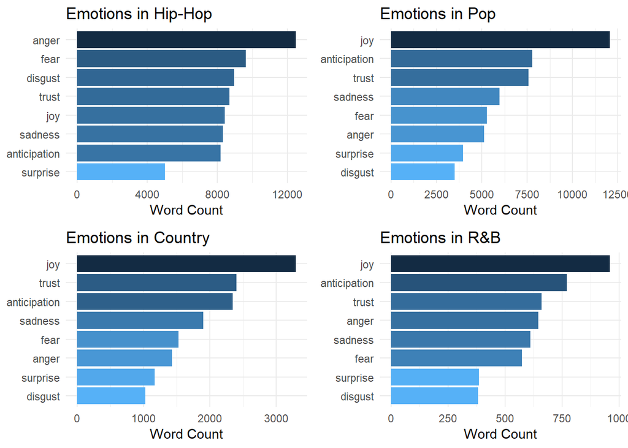

```r
plot1 <- sentiments %>%
  filter(genre %in% "Hip-Hop") %>%
  group_by(sentiment) %>%
  summarise(word_count = n()) %>%
  ungroup() %>%
  mutate(sentiment = reorder(sentiment, word_count)) %>%
  ggplot(aes(sentiment, word_count, fill = -word_count)) +
  geom_col() +
  guides(fill = FALSE) +
  theme_minimal() +
  labs(x = NULL, y = "Word Count") +
  ggtitle("Emotions in Hip-Hop") +
  coord_flip()

plot2 <- sentiments %>%
  filter(genre %in% "Pop") %>%
  group_by(sentiment) %>%
  summarise(word_count = n()) %>%
  ungroup() %>%
  mutate(sentiment = reorder(sentiment, word_count)) %>%
  ggplot(aes(sentiment, word_count, fill = -word_count)) +
  geom_col() +
  guides(fill = FALSE) +
  theme_minimal() +
  labs(x = NULL, y = "Word Count") +
  ggtitle("Emotions in Pop") +
  coord_flip()

plot3 <- sentiments %>%
  filter(genre %in% "Country") %>%
  group_by(sentiment) %>%
  summarise(word_count = n()) %>%
  ungroup() %>%
  mutate(sentiment = reorder(sentiment, word_count)) %>%
  ggplot(aes(sentiment, word_count, fill = -word_count)) +
  geom_col() +
  guides(fill = FALSE) +
  theme_minimal() +
  labs(x = NULL, y = "Word Count") +
  ggtitle("Emotions in Country") +
  coord_flip()

plot4 <- sentiments %>%
  filter(genre %in% "R&B") %>%
  group_by(sentiment) %>%
  summarise(word_count = n()) %>%
  ungroup() %>%
  mutate(sentiment = reorder(sentiment, word_count)) %>%
  ggplot(aes(sentiment, word_count, fill = -word_count)) +
  geom_col() +
  guides(fill = FALSE) +
  theme_minimal() +
  labs(x = NULL, y = "Word Count") +
  ggtitle("Emotions in R&B") +
  coord_flip()

grid.arrange(plot1, plot2, plot3, plot4, ncol = 2)
```

The most negative sentiments we can find in the Hip-Hop music, while the genre of Pop has much more words associated with rather good emotions. Sentiments most prevalent in Hip-Hop music are the ones of anger, fear and disgust. Also, many vulgar, profanity words come mostly from Hip-Hop lyrics and are also included in the top negative words from our “Contribution to Sentiment” graph and wordclouds. The Hip-Hop genre as well as Pop may be groups that would be easy to classify by the sentiment (polarity) predictor.

The Chord Diagram enabled us to visualize the inter-relationships between each genre and emotion.

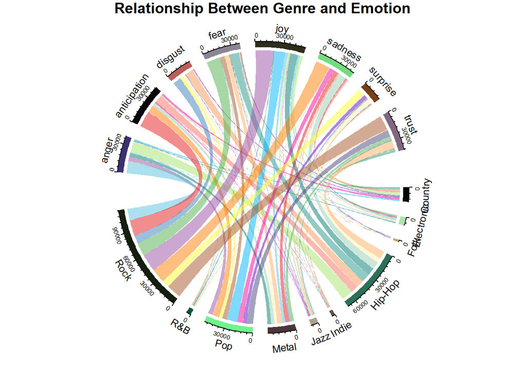

```r
sentiments <- lyrics %>%
  inner_join(get_sentiments("nrc"),by="word")

genre_emotion <- sentiments %>%
  filter(!sentiment %in% c("positive", "negative")) %>%
  count(sentiment, genre) %>%
  group_by(genre, sentiment) %>%
  summarise(sentiment_sum = sum(n)) %>%
  ungroup()


colors <- c("#00B2FF", "#FF0099", "#6600CC","#464680",
            "#a4e46b", "#fb6f62","#f69454", "#24978d","#01796f","#96ceb4",
            "#ffeead","#ffad60","#5bc0de", "#E41A1C", "#377EB8", "#4DAF4A",
            "#984EA3", "#FF7F00", "#FFFF33", "#A65628")

circos.clear()

#Setting the gap size
circos.par(gap.after = c(rep(6, length(unique(genre_emotion[[1]])) - 1), 15,
                         rep(6, length(unique(genre_emotion[[2]])) - 1), 15))

chordDiagram(genre_emotion, col = colors)
title("Relationship Between Genre and Emotion")
```

## 3. Classification

#### 3.1. Extracting polarity

Before classfication we would like to extract polarity and positive/negative proportion features that are going to be used in the model. We used the spread() function to separate the sentiments into columns and mutate() to create a polarity (positive - negative) feature (Liske, 2018).

```r
# Positive / negative ratios and polarity

lyrics_bing <- lyrics %>%
  inner_join(get_sentiments("bing"))
lyrics_polarity <- lyrics_bing %>%
  count(sentiment, song) %>%
  spread(sentiment, n, fill = 0) %>%
  mutate(polarity = positive - negative,
         percent_positive = positive / (positive + negative) * 100,
         percent_negative = negative / (positive + negative) * 100)

# we only need 'genre' variable as well
lyrics_genre <- lyrics %>% select(c("song", "genre"))

# drop duplicates (we are interested in whole song, not observations for each word)
lyrics_song <- unique(lyrics_genre)

# now we are ready to combine the two sets of variables
lyrics_set <- merge(lyrics_song, lyrics_polarity, by = "song")

# we set the genre to factor, to read it as a response variable
lyrics_set$genre <- as.factor(lyrics_set$genre)
```

Genre polarity and sentiment visualization:

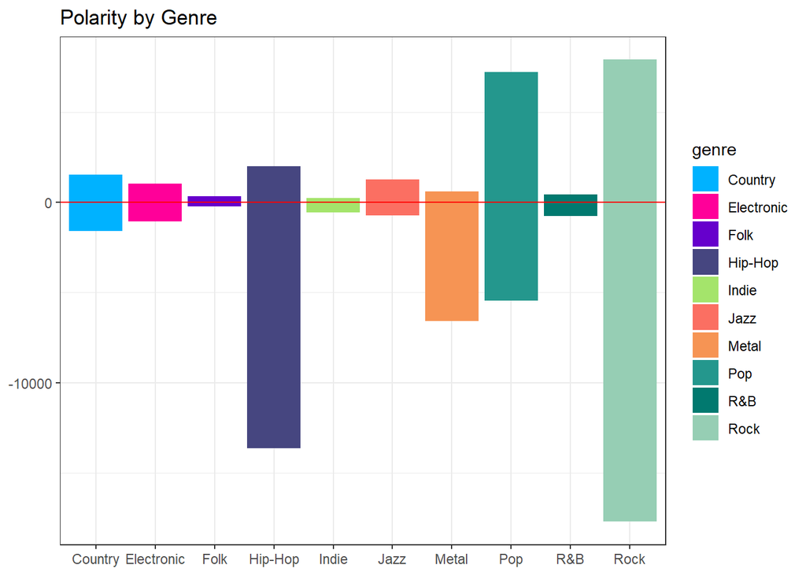

```r
# Genre polarity visualization
lyrics_set %>%
  ggplot( aes(genre, polarity, fill = genre)) +
  geom_col() +
  scale_fill_manual(values = colors) +
  geom_hline(yintercept = 0, color = "red") +
  theme(plot.title = element_text(size = 11)) +
  theme_bw()+
  xlab(NULL) + ylab(NULL) +
  ggtitle("Polarity by Genre")
```

#### 3.2. Support Vector Machine

The used method was the Support Vector Machine with radial kernel and 10 predicted classes. We trained the model according to the given formula on the train set and validated the predictions on the test set. The results are visible in the confusion matrix.

```r
set.seed(123456)
training_obs <- createDataPartition(lyrics_set$genre,
                                    p = 0.7,
                                    list = FALSE)
lyrics.train <- lyrics_set[training_obs,]
lyrics.test  <- lyrics_set[-training_obs,]

# Defining the model formula and training the model
svm.model <- svm(genre ~ negative + positive + polarity + percent_positive + percent_negative,
                 data = lyrics.train)

summary(svm.model)
```

```
##
## Call:
## svm(formula = genre ~ negative + positive + polarity + percent_positive +
##     percent_negative, data = lyrics.train)
##
##
## Parameters:
##    SVM-Type:  C-classification
##  SVM-Kernel:  radial
##        cost:  1
##       gamma:  0.2
##
## Number of Support Vectors:  6566
##
##  ( 861 2085 1399 539 838 124 276 127 249 68 )
##
##
## Number of Classes:  10
##
## Levels:
##  Country Electronic Folk Hip-Hop Indie Jazz Metal Pop R&B Rock
```

```r
svm.pred <- predict(svm.model, lyrics.test)

cm.svm <- confusionMatrix(svm.pred, lyrics.test$genre)
cm.svm
```

```
## Confusion Matrix and Statistics
##
##             Reference
## Prediction   Country Electronic Folk Hip-Hop Indie Jazz Metal  Pop  R&B
##   Country          0          0    0       0     0    0     0    0    0
##   Electronic       0          0    0       0     0    0     0    0    0
##   Folk             0          0    0       0     0    0     0    0    0
##   Hip-Hop          5          4    1     115     3    6    18   20    4
##   Indie            0          0    0       0     0    0     0    0    0
##   Jazz             0          0    0       0     0    0     0    0    0
##   Metal            0          0    0       0     0    0     0    0    0
##   Pop              2          3    3       6     0    3     0   27    0
##   R&B              0          0    0       0     0    0     0    0    0
##   Rock           223         99   24     273    49  108   340  555   50
##             Reference
## Prediction   Rock
##   Country       0
##   Electronic    0
##   Folk          0
##   Hip-Hop      46
##   Indie         0
##   Jazz          0
##   Metal         0
##   Pop          12
##   R&B           0
##   Rock       1531
##
## Overall Statistics
##
##                Accuracy : 0.4739
##                  95% CI : (0.4574, 0.4906)
##     No Information Rate : 0.4501
##     P-Value [Acc > NIR] : 0.002391
##
##                   Kappa : 0.086
##  Mcnemar's Test P-Value : NA
##
## Statistics by Class:
##
##                      Class: Country Class: Electronic Class: Folk
```

[output cut: 11 more lines]

```
## Pos Pred Value              0.51802          NaN         NaN          NaN
## Neg Pred Value              0.91566      0.98527     0.96686       0.8986
## Prevalence                  0.11161      0.01473     0.03314       0.1014
## Detection Rate              0.03258      0.00000     0.00000       0.0000
## Detection Prevalence        0.06289      0.00000     0.00000       0.0000
## Balanced Accuracy           0.62888      0.50000     0.50000       0.5000
##                      Class: Pop Class: R&B Class: Rock
## Sensitivity            0.044850     0.0000      0.9635
## Specificity            0.990096     1.0000      0.1133
## Pos Pred Value         0.482143        NaN      0.4708
## Neg Pred Value         0.834485     0.9847      0.7914
## Prevalence             0.170538     0.0153      0.4501
## Detection Rate         0.007649     0.0000      0.4337
## Detection Prevalence   0.015864     0.0000      0.9212
## Balanced Accuracy      0.517473     0.5000      0.5384
```

```r
# What could be the reason?--the data may be highly unbalanced
prop.table(table(lyrics_set$genre))
```

```
##
##     Country  Electronic        Folk     Hip-Hop       Indie        Jazz
## 0.065246903 0.030120482 0.008145257 0.111573053 0.014932971 0.033344646
##       Metal         Pop         R&B        Rock
## 0.101476328 0.170286781 0.015357203 0.449516375
```

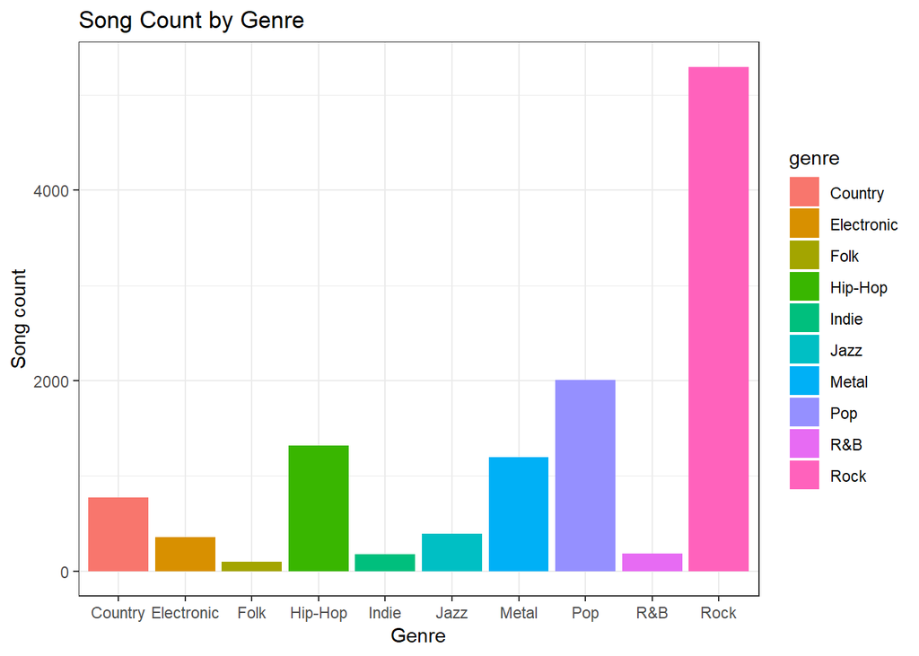

```r
lyrics_set$prop <- as.character.factor(lyrics_set$genre)
lyrics_set$prop <- within(lyrics_set, genre[genre == 'Country'] <- 'Country')
prop <- lyrics_set$prop

# Proportion visualization

ggplot(prop, aes(x = genre, fill = genre)) +
  theme_bw() +
  geom_bar() +
  labs(x = "Genre", y = "Song count", title = "Song Count by Genre")
```

Let us, therefore, perform the classification task once again, yet with some up-sampling.

```r
set.seed(123456)
up_train <- upSample(x = lyrics.train[,-2],
                         y = lyrics.train$genre)

kable(table(up_train$Class))
```

| Var1 | Freq |
| --- | --- |
| Country | 3709 |
| Electronic | 3709 |
| Folk | 3709 |
| Hip-Hop | 3709 |
| Indie | 3709 |
| Jazz | 3709 |
| Metal | 3709 |
| Pop | 3709 |
| R&B | 3709 |
| Rock | 3709 |

```r
# Defining the model formula and training the model
svm.model.2 <- svm(Class ~ negative + positive + polarity + percent_positive + percent_negative,
                 data = up_train)

summary(svm.model.2)
```

```
##
## Call:
## svm(formula = Class ~ negative + positive + polarity + percent_positive +
##     percent_negative, data = up_train)
##
##
## Parameters:
##    SVM-Type:  C-classification
##  SVM-Kernel:  radial
##        cost:  1
##       gamma:  0.2
##
## Number of Support Vectors:  36515
##
##  ( 3709 3695 3666 3227 3709 3681 3709 3701 3709 3709 )
##
##
## Number of Classes:  10
##
## Levels:
##  Country Electronic Folk Hip-Hop Indie Jazz Metal Pop R&B Rock
```

```r
svm.pred.2 <- predict(svm.model.2, lyrics.test)

cm.svm.2 <- confusionMatrix(svm.pred.2, lyrics.test$genre)
cm.svm.2
```

```
## Confusion Matrix and Statistics
##
##             Reference
## Prediction   Country Electronic Folk Hip-Hop Indie Jazz Metal Pop R&B Rock
##   Country          7          2    0       5     3    2     6  10   2   32
##   Electronic       2          2    0       4     0    4     0  18   1   20
##   Folk            26          8    3      26     7   10    14  46   2  128
##   Hip-Hop         12         16    3     199     5    8    71  61   9  151
##   Indie           56         18    3      29     7   22    61 113   7  339
##   Jazz            55         24    5      16    10   42    22 145  11  272
##   Metal           45         26    7      75    13   13   144 103  12  417
##   Pop              4          4    4      13     1    7     3  44   2   31
##   R&B              0          1    0      13     0    3     0  22   3   23
##   Rock            23          5    3      14     6    6    37  40   5  176
##
## Overall Statistics
##
##                Accuracy : 0.1776
##                  95% CI : (0.1651, 0.1906)
##     No Information Rate : 0.4501
##     P-Value [Acc > NIR] : 1
##
##                   Kappa : 0.0882
##  Mcnemar's Test P-Value : <2e-16
##
## Statistics by Class:
##
##                      Class: Country Class: Electronic Class: Folk
## Sensitivity                0.030435         0.0188679   0.1071429
## Specificity                0.981212         0.9856893   0.9237579
## Pos Pred Value             0.101449         0.0392157   0.0111111
## Neg Pred Value             0.935568         0.9701064   0.9923313
## Prevalence                 0.065156         0.0300283   0.0079320
## Detection Rate             0.001983         0.0005666   0.0008499
## Detection Prevalence       0.019547         0.0144476   0.0764873
## Balanced Accuracy          0.505823         0.5022786   0.5154504
##                      Class: Hip-Hop Class: Indie Class: Jazz Class: Metal
## Sensitivity                 0.50508     0.134615     0.35897      0.40223
## Specificity                 0.89286     0.813686     0.83592      0.77585
## Pos Pred Value              0.37196     0.010687     0.06977      0.16842
## Neg Pred Value              0.93489     0.984348     0.97439      0.92000
## Prevalence                  0.11161     0.014731     0.03314      0.10142
## Detection Rate              0.05637     0.001983     0.01190      0.04079
## Detection Prevalence        0.15156     0.185552     0.17054      0.24221
## Balanced Accuracy           0.69897     0.474151     0.59745      0.58904
##                      Class: Pop Class: R&B Class: Rock
## Sensitivity             0.07309  0.0555556     0.11076
## Specificity             0.97643  0.9821634     0.92839
## Pos Pred Value          0.38938  0.0461538     0.55873
## Neg Pred Value          0.83670  0.9852814     0.56050
## Prevalence              0.17054  0.0152975     0.45014
## Detection Rate          0.01246  0.0008499     0.04986
## Detection Prevalence    0.03201  0.0184136     0.08924
## Balanced Accuracy       0.52476  0.5188595     0.51957
```

With the up-sampling, the values were false and the results corrupted, the model turned out to be even weaker in its accuracy.

#### 3.3. Results and conclusions

The sentimental analysis of words provided us some interesting relationships when it comes to genre of a song and its lyrics’ sentiments. We were able to observe some most frequent words within distinct music genres, and the genres’prevailing sentiments. Unfortnately, however, we were not able to make prediction that would classify the genre of a song correctly, basing of a song’s polarity. What could be done to improve the model is for example up-sampling to balance the data while using only the most common genres together with some tuning. What is more, there could be a very low variability of our data when it comes to polarity, and most genres may be simply too similar or neutral in sentiment. An even better idea would be to scrap more songs for bigger representation of scarce genres and balance the proportions in our dataset.

## References

Liske, D. (2018). “Lyric Analysis with NLP & Machine Learning with R.” Data Camp Tutorial. Available at: https://www.datacamp.com/community/tutorials/R-nlp-machine-learning

Liske, D. (2018). “Tidy Sentiment Analysis in R.” Data Camp Tutorial. Availble at: https://www.datacamp.com/community/tutorials/sentiment-analysis-R